# How Intrusive Are My Targeted Ads?

## A log of everyday ad interruptions

Targeted advertising is easy to ignore one ad at a time, but it becomes more interesting when each ad is logged as data. My observations record where an ad appeared, how long it was visible or played for, whether I interacted with it, what topic it seemed to target, and when the observation happened.

> I treated intrusiveness as a mix of frequency and duration: a platform can feel intrusive because ads appear often, because they last longer, or because both things happen together.

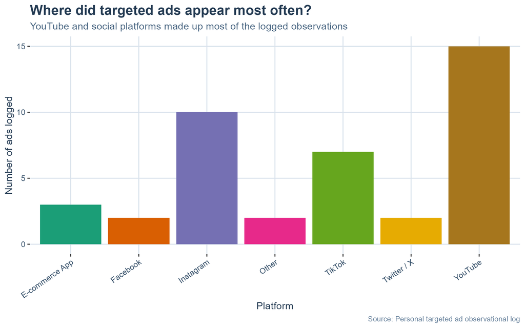

Bar chart showing the number of targeted ads logged for each platform, with YouTube appearing most often among the observed platforms.

The first visualisation shows the volume side of the story. YouTube produced the most logged ads, followed by platforms such as Instagram and TikTok. This matters because even short ads can feel disruptive when they appear repeatedly.

## Duration changes the feeling of the ad

Counting ads only tells part of the story. A static ad recorded as zero seconds is different from a video ad that plays for several seconds before it can be skipped. To compare this, I summarised the data by platform and calculated the average duration for each one.

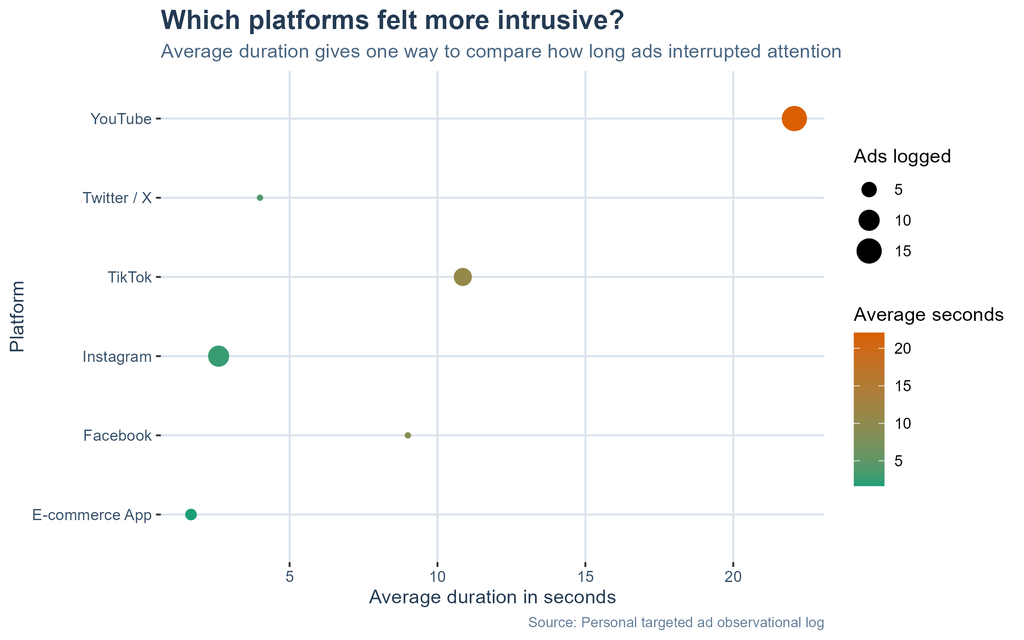

Dot plot comparing the average ad duration in seconds by platform, with dot size showing how many ads were logged for that platform.

This plot shifts attention from “how many” to “how long”. The larger points show where more observations were collected, while the horizontal position shows the average time cost. Platforms with longer average duration are more likely to interrupt attention, even if they did not appear as often.

## Time gives the interruptions context

The timestamp from the Google Form adds another layer to the story. By converting the timestamp into a day and hour, I could check whether the longest ads were concentrated around particular logging times.

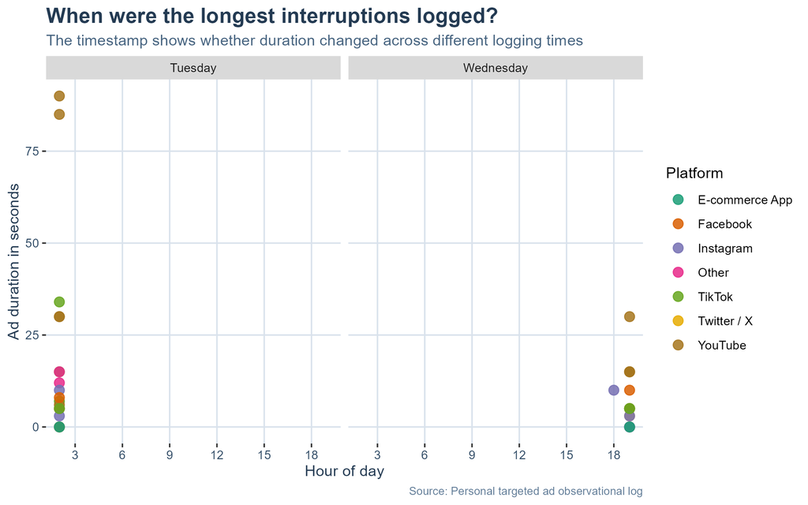

Faceted scatter plot showing ad duration by hour of day, separated by day of week, with points coloured by platform. Data are logged together, so the plot doesn’t look as good

The longest observations stand out clearly against many short or static ads. The newer Project 4 observations were mostly logged in the evening, while the original Project 2 observations were mostly logged earlier. This makes the timestamp useful because it shows that the data is not just about platforms; it is also about the situations when I encountered the ads.

## What the visual story suggests

The main pattern is that targeted ad intrusiveness is not one-dimensional. YouTube stands out for frequency, but the duration plot shows why frequency alone is not enough. Some platforms may appear less often but still feel more disruptive when the ad lasts longer.

For my own digital habits, this suggests that the most intrusive platforms are the ones that combine repeated exposure with longer video-style ads. The visual story also shows why observational logging is useful: individual ads feel forgettable, but the accumulated data makes the pattern easier to see.